# Korean Triage Analysis

## **Aybike Dilek**

### **Date**: 30.01.2021

The project aims to conduct exploratory analyses and to provide outcomes using the Korean Triage dataset.

**About Dataset**

The dataset contains various data points of patients who visited emergency departments between 2016-10 to 2017-09. There are 24 variables, with 1267 observations.

**Overview**

The dataset and packages were uploaded. The first five rows and data types of the columns were investigated. Some columns contained missing values like NRS_pain. Besides, the data types of some columns were not the desired type.

```python
import pandas as pd
import matplotlib.pyplot as plt
import numpy as np
import seaborn as sns
import warnings
warnings.filterwarnings('ignore')
from google.colab import files
uploaded = files.upload()
```

Upload widget is only available when the cell has been executed in the current browser session. Please rerun this cell to enable.

```
Saving pone.0216972.s001.xlsx to pone.0216972.s001.xlsx
```

```python
data= pd.read_excel("pone.0216972.s001.xlsx")
print(data.head())
```

```
   Group  Sex   Age  ...  Length of stay_min  KTAS duration_min  mistriage
0      2    2  71.0  ...                86.0           5.000000          1
1      1    1  56.0  ...                64.0           3.950000          1
2      2    1  67.5  ...               862.0           1.000000          1
3      1    2  71.0  ...               108.0           9.833333          1
4      1    2  58.0  ...               109.0           6.600000          1

[5 rows x 24 columns]
```

```python
print(data.info())
```

```
<class 'pandas.core.frame.DataFrame'>
RangeIndex: 1267 entries, 0 to 1266
Data columns (total 24 columns):
 #   Column                    Non-Null Count  Dtype
---  ------                    --------------  -----
 0   Group                     1267 non-null   int64
 1   Sex                       1267 non-null   int64
 2   Age                       1267 non-null   float64
 3   Patients number per hour  1267 non-null   int64
 4   Arrival mode              1267 non-null   int64
 5   Injury                    1267 non-null   int64
 6   Chief_complain            1267 non-null   object
 7   Mental                    1267 non-null   int64
 8   Pain                      1267 non-null   int64
 9   NRS_pain                  711 non-null    float64
```

[output cut: 17 more lines]

**Preprocessing**

The Korean signs and an irregular entry, which was "36." in the DBP column, were removed. The data types of some columns were changed like SBP, DBP, and HR.

```python
data=data[data["SBP"].str.isnumeric()]
data=data[data["DBP"].str.isnumeric()]
data=data[data["HR"].str.isnumeric()]
data=data[data["RR"].str.isnumeric()]
BT_update=data["BT"].str.isalpha()
data=data[~BT_update]
print(data)
```

```
      Group  Sex   Age  ...  Length of stay_min  KTAS duration_min  mistriage
0         2    2  71.0  ...                86.0           5.000000          1
1         1    1  56.0  ...                64.0           3.950000          1
2         2    1  67.5  ...               862.0           1.000000          1
3         1    2  71.0  ...               108.0           9.833333          1
4         1    2  58.0  ...               109.0           6.600000          1
...     ...  ...   ...  ...                 ...                ...        ...
1262      2    2  78.9  ...              1995.0           3.000000          0
1263      2    2  80.8  ...              1000.0           2.000000          0
1264      2    2  80.9  ...               310.0           4.000000          0
1265      2    1  81.0  ...               475.0           5.000000          0
1266      2    2  86.9  ...               887.0           2.000000          0

[1232 rows x 24 columns]
```

*The drop_duplicates has been made to make sure that there were no duplicate rows in the dataset.*

```python
data = data.drop_duplicates()
```

```python
data["SBP"] = pd.to_numeric(data["SBP"])
data["DBP"] = pd.to_numeric(data["DBP"])
data["HR"] = pd.to_numeric(data["HR"])
data["RR"] = pd.to_numeric(data["RR"])
data["BT"] = pd.to_numeric(data["BT"])
```

**Statistics**

The histogram charts of the Age, SBP, DBP, HR, Length-of-Stay-Min, KTAS-Duration-Min were displayed. (Figure.1)

*Figure.1 The Histogram Charts*

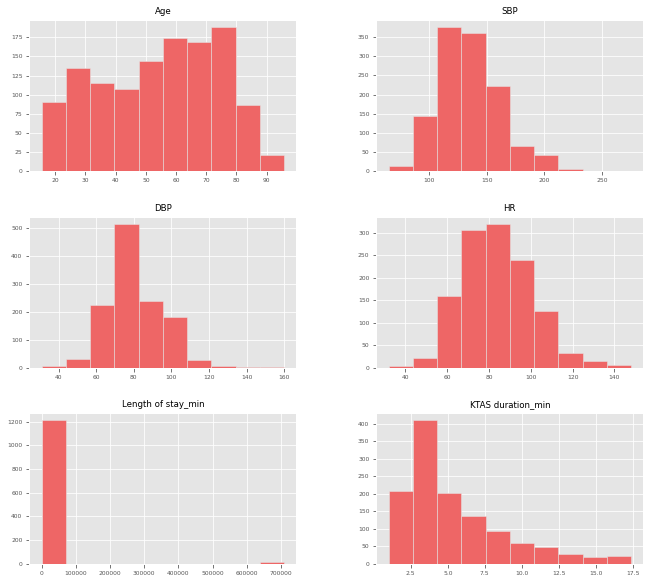

```python
cols=["Age","SBP","DBP","HR","Length of stay_min","KTAS duration_min"]
plt.style.use('ggplot')
plt.rcParams.update({'font.size': 6})
data[cols].hist(figsize=(11, 10),color="#EE6666",edgecolor='#E6E6E6')
plt.show()
```

KTAS-Duration-Min had the Skewed Right distribution. Besides, Length-of-Stay-Min may have unreliable records according to the output.

```python
from scipy import stats
#alpha was accepted as 0.05
for i in ["SBP","DBP","HR"]:
  print(str(i),stats.normaltest(data[i]))
```

```
SBP NormaltestResult(statistic=108.04404301584421, pvalue=3.45568507941354e-24)
DBP NormaltestResult(statistic=51.19307544059589, pvalue=7.648299959535874e-12)
HR NormaltestResult(statistic=33.231994732230035, pvalue=6.07804669953662e-08)
```

The .normaltest was done for SBP, DBP, and HR. Their p-values were smaller than alpha (0.05). The null hypothesis, data has a normal distribution, was rejected.

The summary of the columns was displayed.

```python
cols=["Age","SBP","DBP","HR","Length of stay_min","KTAS duration_min"]
print(data[cols].describe().round())
```

```
          Age     SBP     DBP      HR  Length of stay_min  KTAS duration_min
count  1232.0  1232.0  1232.0  1232.0              1232.0             1232.0
mean     54.0   134.0    80.0    84.0             11296.0                6.0
std      20.0    27.0    15.0    16.0             81562.0                3.0
min      16.0    65.0    31.0    32.0                 0.0                1.0
25%      37.0   115.0    70.0    72.0               133.0                3.0
50%      56.0   130.0    80.0    81.0               274.0                4.0
75%      71.0   150.0    90.0    96.0               614.0                7.0
max      96.0   275.0   160.0   148.0            709510.0               17.0
```

**Exploratory Data Analysis**

**Analysis 1:**

The average SBP, DBP, HR, and BT by Sex and KTAS-Expert-Level were displayed. (Table.1)

*Table.1 The average SBP, DBP, HR and BT by Sex and KTAS-Expert-Level*

```python
data.pivot_table(index='KTAS_expert', columns='Sex',
                    aggfunc={'SBP':'mean', 'DBP' : 'mean','HR' : 'mean','BT' : 'mean'}).round().rename_axis(
                        index={'KTAS_expert': 'KTAS-Expert-Level'})
```

| Sex KTAS-Expert-Level | BT 1 | BT 2 | DBP 1 | DBP 2 | HR 1 | HR 2 | SBP 1 | SBP 2 |
| --- | --- | --- | --- | --- | --- | --- | --- | --- |
| 1 | 36.0 | 36.0 | 63.0 | 88.0 | 82.0 | 108.0 | 98.0 | 124.0 |
| 2 | 37.0 | 37.0 | 79.0 | 79.0 | 81.0 | 83.0 | 131.0 | 130.0 |
| 3 | 37.0 | 37.0 | 79.0 | 81.0 | 83.0 | 86.0 | 134.0 | 138.0 |
| 4 | 37.0 | 37.0 | 79.0 | 81.0 | 84.0 | 84.0 | 133.0 | 136.0 |
| 5 | 36.0 | 37.0 | 77.0 | 81.0 | 86.0 | 86.0 | 133.0 | 133.0 |

The average DBP and HR of Males (2) were equal or higher than Females (1) in each KTAS-Expert-Level. Females had lower SBP and DBP, and Males had higher HR and DBP in KTAS-Expert-Level-1, compared to the other levels.

**Analysis 2:**

The relationship between the SBP and DBP was investigated using Sex as hue. (Figure.2) Additionally, the Pearson correlation coefficient was displayed.

*Figure.2 The Relationship between SBP and DBP*

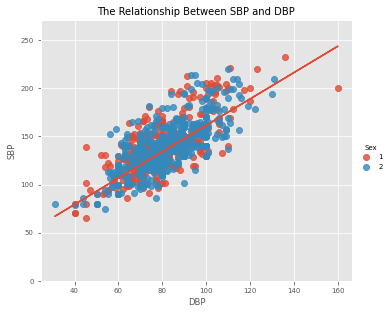

```python
plt.style.use('ggplot')
plt.rcParams.update({'font.size': 7})
SET_1=data
sns.lmplot(x="DBP", y="SBP", data=SET_1, fit_reg=False, hue='Sex', legend=True, height=4, aspect=1.2)
(s, i) = np.polyfit(SET_1["DBP"],SET_1["SBP"], 1)
plt.plot(SET_1["DBP"], s*SET_1["DBP"]+i)
plt.title("The Relationship Between SBP and DBP",fontsize="10")
plt.ylim(0,270)
plt.show()
```

```python
r = np.corrcoef(data.SBP, data.DBP)
print(round(r[0,1],2))
```

```
0.77
```

There was a positive relationship between SBP and DBP with a 0.77 correlation coefficient.

**Analysis 3:**

The Arrival Modes of the KTAS-Expert-Level-1 were investigated. (Figure.3)

*Figure.3 The Arrival Modes of the KTAS-Expert-Level-1*

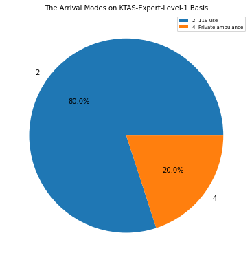

```python
SET_2=data[data["KTAS_expert"]==1].groupby('Arrival mode')['Chief_complain'].count()
plt.figure(figsize=(6.5, 6.5), edgecolor='w')
plt.style.use('default')
SET_2.plot.pie(autopct='%1.1f%%')
plt.title("The Arrival Modes on KTAS-Expert-Level-1 Basis",fontsize=10)
plt.legend(["2: 119 use","4: Private ambulance"],loc='upper right',fontsize=7)
plt.ylabel('')
plt.show()
```

119 use and Private ambulance were preferred as the arrival. KTAS-Expert-Level-1 has the highest priority. The patients of this level may need intervention during the hospital arrival, so they may have been favored because both had technical equipment.

**Analysis 4:**

The median age of the Dispositions was investigated. (Figure.4)

*Figure.4 The Median Age of the Dispositions*

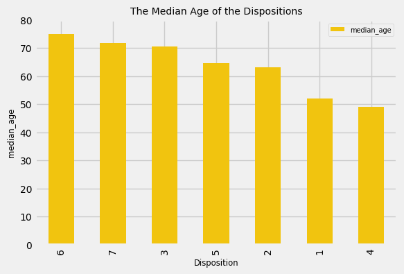

```python
SET_3=data.groupby('Disposition').agg({"Age": "median"}).sort_values(["Age"],ascending=False)
plt.style.use('fivethirtyeight')
plt.rcParams.update({'font.size': 7})
SET_3.plot(kind="bar",title="The Median Age of the Dispositions",fontsize=10,color="#F1C40F",figsize=(6, 4),
           label="median_age")
plt.ylabel("median_age")
plt.ylim(0,80)
plt.legend(["median_age"],loc ="upper right")
plt.show()
```

The Death (6) had the highest, and the discharges (4,1) had the lowest median age. The reasons could be body balancing mechanisms of elders may be insufficient, or they may have different diseases simultaneously.

**Analysis 5:**

The patient counts by Mentals and KTAS-Expert-Level were investigated. (Figure.5)

*Figure.5 The Patient Counts by Mentals and KTAS-Expert-Level*

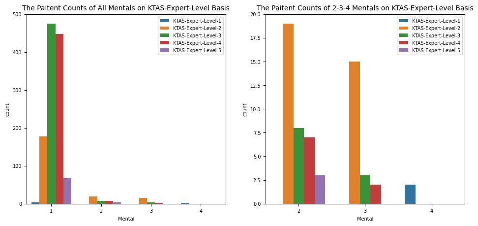

```python
SET_4=data[data["Mental"] != 1]
plt.style.use('default')
plt.rcParams.update({'font.size': 7})
fig, ax =plt.subplots(1,2,figsize=(11.5,5))
sns.countplot(x="Mental", hue="KTAS_expert", data=data, ax=ax[0])
ax[0].set_title("The Paitent Counts of All Mentals on KTAS-Expert-Level Basis",fontsize=10)
ax[0].set_ylim(0,500)
sns.countplot(x="Mental", hue="KTAS_expert", data=SET_4, ax=ax[1])
ax[1].set_title("The Paitent Counts of 2-3-4 Mentals on KTAS-Expert-Level Basis",fontsize=10)
ax[1].set_ylim(0,20)
for i in range(2):
  ax[i].legend(["KTAS-Expert-Level-1","KTAS-Expert-Level-2","KTAS-Expert-Level-3","KTAS-Expert-Level-4",
                "KTAS-Expert-Level-5"],loc='upper right',fontsize=7)
fig.show()
```

The highest volume belonged to the Alert (1), which mostly had KTAS-Expert-Level-3. The Alert was removed and plotted again to examine in detail. As the mental status worsened, patients were prioritized. The Unconsciousness (4) was leveled as KTAS-Expert-Level-1 for all. That may because they need respiratory support and HR control mostly.

**Analysis 6:**

The median KTAS-Expert-Level, KTAS-Duration-Min, Length-of-Stay-Min, and the Mistriage-Proportion by Group and NRS-Pain-Class were displayed. (Table.2)

*Table.2 The median KTAS-Expert-Level, KTAS-Duration-Min, Length-of-Stay-Min, and the Mistriage-Proportion by Group and NRS-Pain-Class*

```python
warnings.filterwarnings('ignore')
condition_one = (data["NRS_pain"] >=1) & (data["NRS_pain"] < 5)
condition_two = (data["NRS_pain"] >=5)
conditions = [condition_one, condition_two]
choices = ["0", "1"]
data["NRS-Pain-Class"] = np.select(conditions, choices, default="")

SET_5=data[data["NRS-Pain-Class"].str.isnumeric()]

SET_5["NRS-Pain-Class"] = pd.to_numeric(SET_5["NRS-Pain-Class"])

SET_5.loc[SET_5['mistriage'] == 2, 'mistriage'] = 1
```

NRS-Pain-Classes were created manually. Class-0 and Class-1 contained respectively 1-4, 5-10 pain scores. The empty rows were removed. Under-triage (2) was changed as 1 for the Mistriage-Proportion calculation.

```python
SET_5.pivot_table(index='NRS-Pain-Class', columns='Group',
                    aggfunc={'KTAS_expert':'median',
                             'KTAS duration_min':'median',
                             'mistriage' : 'mean',
                             'Length of stay_min' : 'median'}).round(2).rename(
                                 columns={'KTAS_expert': 'KTAS-Expert-Level',
                                          'KTAS duration_min': 'KTAS-Duration-Min',
                                          'Length of stay_min':'Length-of-Stay-Min',
                                          'mistriage': 'Mistriage-Proportion'})
```

| Group NRS-Pain-Class | KTAS-Duration-Min 1 | KTAS-Duration-Min 2 | KTAS-Expert-Level 1 | KTAS-Expert-Level 2 | Length-of-Stay-Min 1 | Length-of-Stay-Min 2 | Mistriage-Proportion 1 | Mistriage-Proportion 2 |
| --- | --- | --- | --- | --- | --- | --- | --- | --- |
| 0 | 6.58 | 3.0 | 4 | 4 | 133.0 | 561.0 | 0.13 | 0.12 |
| 1 | 6.71 | 3.0 | 3 | 3 | 160.5 | 482.5 | 0.11 | 0.29 |

KTS-Duration did not change significantly with-in classes. Regional ED (2) had a lower KTS-Duration than Local ED (1) in both classes. Class-1 had a higher KTAS-Expert-Level in both groups. Length-of-Stay-Minutes deviated in both groups and classes. Mistriage-Proportion of Class-1 in Regional ED was ~%17 more than other combinations.

Since Regional ED is advance, patients, who were seriously ill, may be preferred. Therefore, the Length-of-Stay-Min of Regional ED may be higher.

Class-1 cases may be more difficult short KTS-Duration could be a disadvantage in Mistriage-Proportion.

**Reference**

- https://figshare.com/articles/dataset/Triage_accuracy_and_causes_of_mistriage_using_the_Korean_Triage_and_Acuity_Scale/9779267?file=17515730

```python
!jupyter nbconvert --to html Korean_Triage_Analysis.ipynb
```